# act_report

## Report: Analysing and visualizing data for the WeRateDogs tweet archive

The analysis was carried out on the final data from the data wrangling step. The following analysis was done on the final master data

1. Which are the most common dog stage?
2. What is the Most popular dog name?
3. What is the Most used Twitter Source?
4. What is the correlation between retweet and favourite counts?

For the the first question, we used plotted a bar chart of the different dog stages while excluding the dog stages with "None" as value. The result is shown below

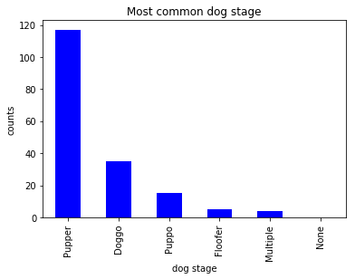

From the chart displayed above, we are able to see that the Pupper dog stage is the most common dog stage in the analysis

The second question is about dog names. In this analysis we want to know which names are common among dogs used in the Tweet, to answer this question, I used another bar chart displayed below

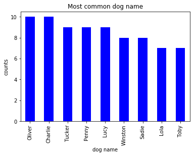

From the chart, we can see nine(9) most used name across the rating data with Oliver and Charlie being top in this analysis with counts of 10.

The third question is about the sources of tweets, the insight here is to tell us the most used source in the rating and tweets. This is supposed to help us the most used platform bu the users. The bar chart below gives the insight to the question

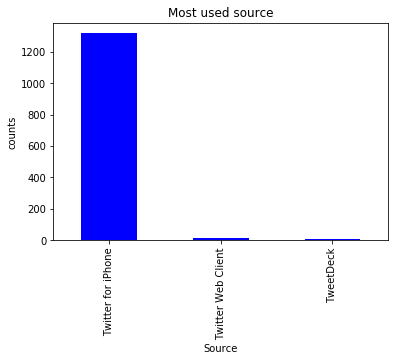

The last insight is about the correlation between the retweet and favorite counts. This was done with a scatter diagram between the two variables as shown below

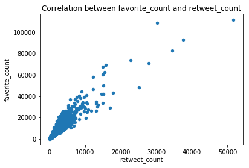

From this scatter diagram, we can see that there is a positive correlation between favorite and retweet count. We can therefore conclude that the favorite count increases as the retweet increases.